# US GNP ARMA11

Dawu Liu

**(c) Use the MLE to fit an ARMA(1,1) model.**

**1. Read in the data**

**(a)** Plot the data.

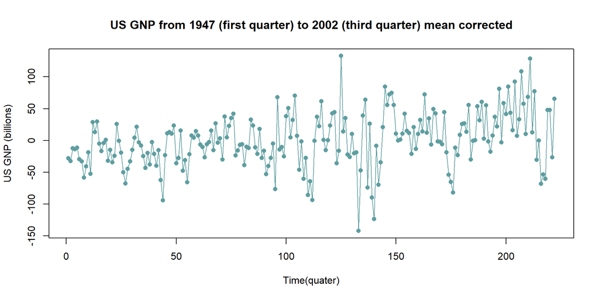

**(b)** Use the plot to make a preliminary assessment of stationarity.

There appears to be a no trend in the data(maybe slightly upward but hard to tell). The variance doesn’t vary much, there doesn’t appear to be any periodicity/seasonality. The data might be stationary, or close to stationary.

**(c)** Plot the sample acf/pacf.

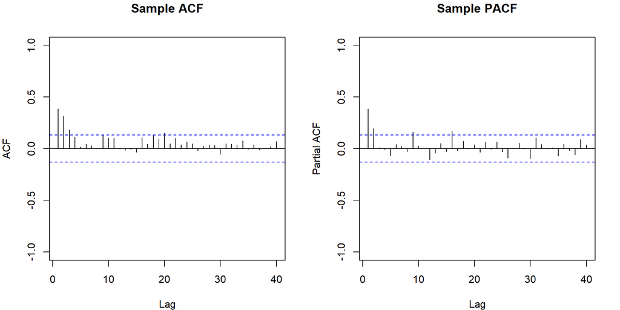

**(d)** Use the plot to make observations about possible orders of dependency.

We can see the acf decays after lag > 0 in the sample ACF plot. The partial acf cuts off after lag = 2 in the sample PACF plot. After lag = 2 , only 2 pacf are beyond the 95% CI. This might indicate the order of dependency is p=2, AR(2).

**2. Estimate the parameters in the specified model using the specified method.**

```
##
## Call:
## arima(x = y, order = c(1, 0, 1), include.mean = FALSE, method = "ML")
##
## Coefficients:
##          ar1      ma1
##       0.7019  -0.3698
## s.e.  0.0954   0.1209
##
## sigma^2 estimated as 1465:  log likelihood = -1124.27,  aic = 2252.53
```

**(a)** Give the estimated coefficients.

The estimated coefficients are: $\hat\phi_1 = 0.7019$, $\hat\theta_1 = -0.3698$, $\hat\sigma^2 = 1465.05$

**(b)** Give the value of the AIC or AICC.

The AIC value is 2252.53

**(c)** Plot the model and sample acf/pacf.

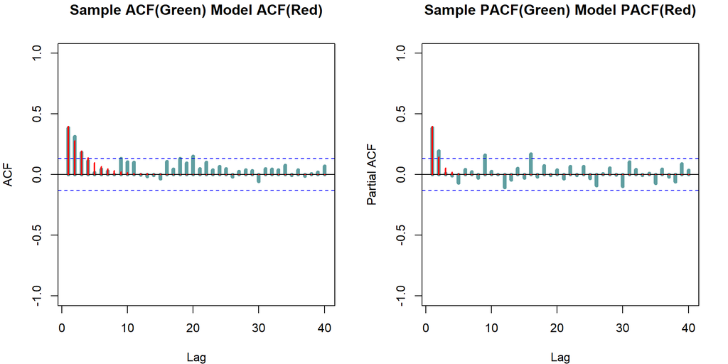

**(d)** Use the plot from (c) to assess the quality of the model fit.

The model acf does capture the significance of sample acf at lag = 1,2,3, at decent accurate level. In the pacf plot, the model pacf and sample pacf are about the same at lag = 1, but different a bit at lag = 2. The model is a ‘decent’ fit for the sample, not as good as the AR(2) model.

**3. Analyze the standardized residuals.**

**(a)** Plot the standardized residuals.

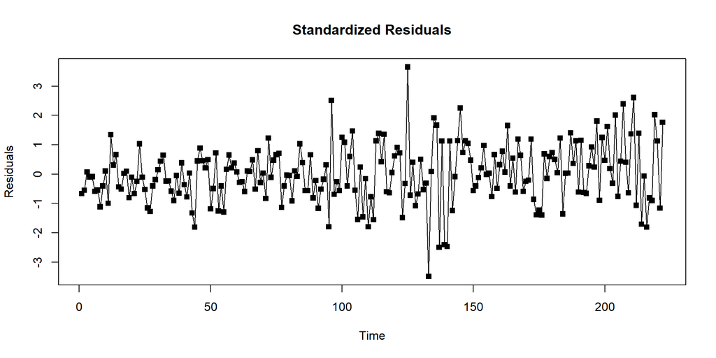

**(b)** Plot the sample acf/pacf for the standardized residuals.

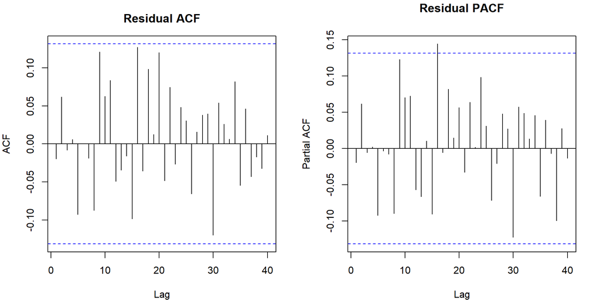

**(c)** Assess the plots for the hypothesis that the residuals are iid.

There is no pattern in the residuals plot. All the residuals acf are within the 95%CI bound at lag > 0, only one residuals pacf is beyond the 95%CI bound at lag > 0. The plots support the hypothesis that residuals being iid.

**(d)** Evaluate the Ljung-Box and McLeod-Li statistics and indicate if they support rejection of the iid hypothesis.

```r
# 3 (d)
#Ljung-Box test
Box.test(arma11resid, lag = 20, type = "Ljung", fitdf = 0)$p.value
```

```
## [1] 0.2336428
```

```r
#McLeod-Li test
Box.test(arma11resid^2, lag = 20, type = "Ljung", fitdf = 0)$p.value
```

```
## [1] 6.716775e-08
```

With lag = 20, the p-values for Ljung-Box and McLeod-Li statistical tests are 0.2336 and 6.717e-08 respectively. LB test fails to reject the iid hypothesis at level 0.05, and ML test supports the rejection of the iid hypothesis at level 0.05.

**(e)** Give a final assessment on the validity of the iid hypothesis.

Plots in b) support the iid hypothesis, one test in d) fails to reject the iid hypothesis while another one supports the rejecttion of iid hypothesis. We conclude that the residuals behave like iid noise.

**4. Use the results to give a summary evaluation about the quality of the fitted model.**

This fitted model ARMA(1,1) is a decent fit for the data. The model acf/pacf captures the the significance of the sample acf/pacf at a decent accuracy at first a few lags. The residuals behave like iid.

**(d) Use the results from (a) and (c) to decide which model is best and give a reason for your choice.**

**AR(2)** is the best out of the three models. It has the smallest AIC out of the three. Its model acf/pacf fit the sample acf/pacf the best. It’s residual ACF/PACF plots have the least count that is outside the 95% CI.

```r
knitr::opts_chunk$set(echo=FALSE, warning=FALSE, message=FALSE)
library(itsmr)
library(TSA)
data = read.delim("E:/2021 Fall/STAT 485/data/gnp-47-02D.txt", header = FALSE)
y = data$V1 - mean(data$V1)
# 1 (a)
plot(y, type="o", pch=16, col="cadetblue", xlab="Time(quater)", ylab="US GNP (billions)",
     main="US GNP from 1947 (first quarter) to 2002 (third quarter) mean corrected")
# 1 (c)
par(mar=c(4,4,3,2), mfrow=c(1,2))
acf.sample = acf(y, lag.max = 40, plot = FALSE)
plot(acf.sample, ylim=c(-1,1), main="Sample ACF")
pacf.sample = pacf(y, lag.max = 40, plot = FALSE)
plot(pacf.sample, ylim=c(-1,1), main="Sample PACF")
# 2 (a) (b)
arma11 = arima(y, order = c(1,0,1), method = "ML", include.mean = FALSE)
arma11
# 2 (c)
arma11model.acf = ARMAacf(ar=c(arma11$coef[1]), ma=c(arma11$coef[2]), lag.max = 40, pacf = FALSE)
arma11model.pacf = ARMAacf(ar=c(arma11$coef[1]), ma=c(arma11$coef[2]), lag.max = 40, pacf = TRUE)

par(mar=c(4,4,3,2), mfrow=c(1,2))

arma11acf.sample = acf(y, lag.max = 40, plot = FALSE)
plot(arma11acf.sample, ylim=c(-1,1), lwd = 5, col="cadetblue", main="Sample ACF(Green) Model ACF(Red)")
points(arma11model.acf[-1], col="red", type="h", lwd = 2)

arma11pacf.sample = pacf(y, lag.max = 40, plot = FALSE)
plot(arma11pacf.sample, ylim=c(-1,1), lwd = 5, col="cadetblue", main="Sample PACF(Green) Model PACF(Red)")
points(arma11model.pacf, col="red", type="h", lwd = 2)
# 3 (a)
arma11resid = rstandard(arma11)
plot(arma11resid , type="o", pch=15, ylab="Residuals", main="Standardized Residuals")
# 3 (b)
par(mar=c(4,4,3,2), mfrow=c(1,2))
arma11acf.resid = acf(arma11resid, lag.max = 40, plot = TRUE, main="Residual ACF")
arma11pacf.resid = pacf(arma11resid, lag.max = 40, plot = TRUE, main="Residual PACF")
# 3 (d)
#Ljung-Box test
Box.test(arma11resid, lag = 20, type = "Ljung", fitdf = 0)$p.value
#McLeod-Li test
Box.test(arma11resid^2, lag = 20, type = "Ljung", fitdf = 0)$p.value
```